# Spatial analyses of 2020-21 excess mortality in CH

Mortality data preparation (*Sterbeort* based)

# Mortality data 2015-2021

## Source

Custom file delivered by BfS covering 2021 period and standardizing municipalities to Jul 2021.

Using **Sterbeort** (*the municipality where the person died*) as unit of analysis.

```r
s_deaths_2015_2021 <- read_csv("data-raw/BfS-closed/05OCT21_Lieferung_Panczak.csv",
                               col_types = cols(year = col_integer(),
                                                month = col_integer(),
                                                COUNT = col_integer()),
                               locale = readr::locale(encoding = "latin1")) %>%
  mutate(sex = if_else(sex == "F", "Female", "Male"),
         nationality = if_else(nationality == "Schweiz", "Swiss", "Foreigner")) %>%
  rename(GMDNAME = community) %>%
  # hyphen in name >> doesnt link to spatial data
  mutate(GMDNAME = if_else(GMDNAME == "La Grande-Béroche", "La Grande Béroche", GMDNAME)) %>%
  # name change? >> resolved with Cordula
  mutate(GMDNAME = if_else(GMDNAME == "Klosters-Serneus", "Klosters", GMDNAME)) %>%
  group_by(year, month, canton, GMDNAME, agegroup, sex, nationality) %>%
  summarise(deaths = sum(COUNT)) %>%
  ungroup()
```

Description of data:

```
The data contains 219911 observations of the following 8 variables:
  - year: n = 219911, Mean = 2017.81, SD = 1.90, Median = 2018.00, MAD = 2.97, range: [2015, 2021], Skewness = 0.02, Kurtosis = -1.19, 0% missing
  - month: n = 219911, Mean = 6.23, SD = 3.52, Median = 6.00, MAD = 4.45, range: [1, 12], Skewness = 0.12, Kurtosis = -1.25, 0% missing
  - canton: 26 entries, such as BE (13.49%); ZH (12.48%); VD (9.25%) and 23 others (0 missing)
  - GMDNAME: 2132 entries, such as Zürich (1.11%); Bern (0.92%); Lausanne (0.89%) and 2129 others (0 missing)
  - agegroup: 10 entries, such as [80-90) (31.25%); [90-116) (24.78%); [70-80) (19.43%) and 7 others (0 missing)
  - sex: 2 entries, such as Male (50.46%); Female (49.54%); NA (0 missing)
  - nationality: 2 entries, such as Swiss (85.47%); Foreigner (14.53%); NA (0 missing)
  - deaths: n = 219911, Mean = 2.01, SD = 3.29, Median = 1.00, MAD = 0.00, range: [1, 118], Skewness = 9.16, Kurtosis = 125.25, 0% missing
```

Data summary

| Name | s_deaths_2015_2021 |
| --- | --- |
| Number of rows | 219911 |
| Number of columns | 8 |
| _______________________ |  |
| Column type frequency: |  |
| character | 5 |
| numeric | 3 |
| ________________________ |  |
| Group variables | None |

**Variable type: character**

| skim_variable | n_missing | complete_rate | min | max | empty | n_unique | whitespace |
| --- | --- | --- | --- | --- | --- | --- | --- |
| canton | 0 | 1 | 2 | 2 | 0 | 26 | 0 |
| GMDNAME | 0 | 1 | 2 | 27 | 0 | 2132 | 0 |
| agegroup | 0 | 1 | 6 | 8 | 0 | 10 | 0 |
| sex | 0 | 1 | 4 | 6 | 0 | 2 | 0 |
| nationality | 0 | 1 | 5 | 9 | 0 | 2 | 0 |

**Variable type: numeric**

| skim_variable | n_missing | complete_rate | mean | sd | p0 | p25 | p50 | p75 | p100 | hist |
| --- | --- | --- | --- | --- | --- | --- | --- | --- | --- | --- |
| year | 0 | 1 | 2017.81 | 1.90 | 2015 | 2016 | 2018 | 2019 | 2021 | ▇▅▅▅▆ |
| month | 0 | 1 | 6.23 | 3.52 | 1 | 3 | 6 | 9 | 12 | ▇▅▅▅▇ |
| deaths | 0 | 1 | 2.01 | 3.29 | 1 | 1 | 1 | 2 | 118 | ▇▁▁▁▁ |

441,154 deaths by year:

|  | year | Deaths |
| --- | --- | --- |
| 1 | 2015 | 67011 |
| 2 | 2016 | 64314 |
| 3 | 2017 | 66276 |
| 4 | 2018 | 66380 |
| 5 | 2019 | 67094 |
| 6 | 2020 | 75696 |
| 7 | 2021 | 34383 |

## Codes of geographical areas

There were 2,163 municipalities in Jul 2021 in CH.

31 had no deaths recorded during the study period.

|  | GMDNAME | KTNAME |
| --- | --- | --- |
| 1 | Meienried | BE |
| 2 | Diemerswil | BE |
| 3 | Schelten | BE |
| 4 | Châtel-sur-Montsalvens | FR |
| 5 | Villarsel-sur-Marly | FR |
| 6 | Unterramsern | SO |
| 7 | Kilchberg (BL) | BL |
| 8 | Gonten | AI |
| 9 | Rüte | AI |
| 10 | Schlatt-Haslen | AI |

[output cut: 21 more lines]

## Age groups

Original age groups:

```
agegroup <character>
# total N=219911 valid N=219911 mean=8.30 sd=1.68

Value    |     N | Raw % | Valid % | Cum. %
-------------------------------------------
[0-10)   |  1714 |  0.78 |    0.78 |   0.78
[10-20)  |   762 |  0.35 |    0.35 |   1.13
[20-30)  |  1927 |  0.88 |    0.88 |   2.00
[30-40)  |  2860 |  1.30 |    1.30 |   3.30
[40-50)  |  6461 |  2.94 |    2.94 |   6.24
[50-60)  | 15292 |  6.95 |    6.95 |  13.19
[60-70)  | 24946 | 11.34 |   11.34 |  24.54
[70-80)  | 42723 | 19.43 |   19.43 |  43.97
[80-90)  | 68733 | 31.25 |   31.25 |  75.22
[90-116) | 54493 | 24.78 |   24.78 | 100.00
<NA>     |     0 |  0.00 |    <NA> |   <NA>
```

```r
s_deaths_2015_2021 %<>%
  mutate(
    age = case_when(
      agegroup == "[0-10)" ~   "<40",
      agegroup == "[10-20)" ~  "<40",
      agegroup == "[20-30)" ~  "<40",
      agegroup == "[30-40)" ~  "<40",

      agegroup == "[40-50)" ~  "40-49",
      agegroup == "[50-60)" ~  "50-59",
      agegroup == "[60-70)" ~  "60-69",
      agegroup == "[70-80)" ~  "70-79",

      agegroup == "[80-90)" ~  "80+",
      agegroup == "[90-116)" ~ "80+" ,
      TRUE ~                    agegroup)
  ) %>%
  select(-agegroup) %>%
  group_by(GMDNAME, year, month, canton, sex, age, nationality) %>%
  summarise(deaths = sum(deaths)) %>%
  ungroup()
```

```
age <character>
# total N=188909 valid N=188909 mean=4.97 sd=1.33

Value |     N | Raw % | Valid % | Cum. %
----------------------------------------
<40   |  6083 |  3.22 |    3.22 |   3.22
40-49 |  6461 |  3.42 |    3.42 |   6.64
50-59 | 15292 |  8.09 |    8.09 |  14.74
60-69 | 24946 | 13.21 |   13.21 |  27.94
70-79 | 42723 | 22.62 |   22.62 |  50.56
80+   | 93404 | 49.44 |   49.44 | 100.00
<NA>  |     0 |  0.00 |    <NA> |   <NA>
```

## Distribution of death counts

Obviously highly skewed.  
Note: No zeroes here yet! No pop denominator either!

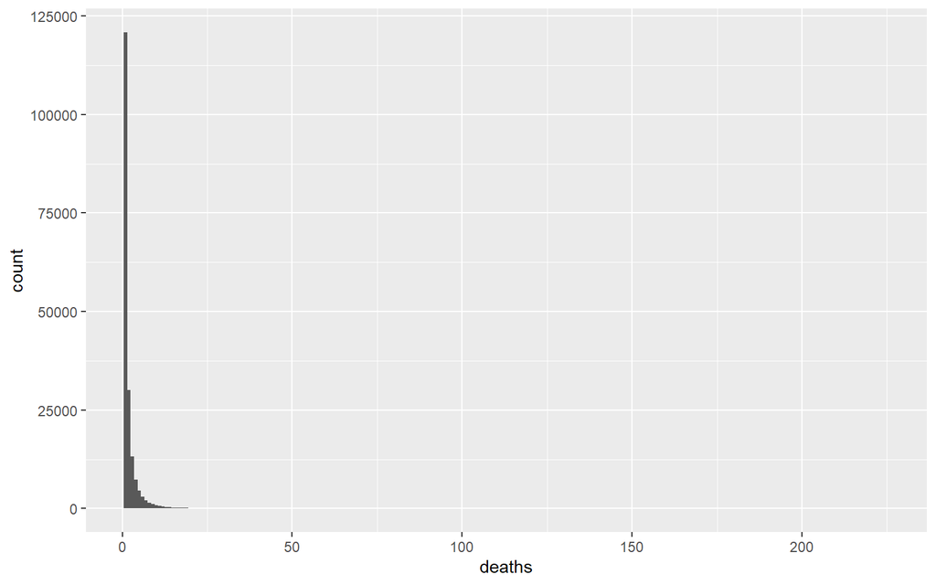

## Filling with zeroes

All possible combinations of `year, month, canton, municipality, age, sex & nationality` are used and then empty strata are filled with zeroes.

This expansion also includes municipalities with zero deaths described above.

```r
s_deaths_2015_2021_exp <-
  raum %>%
  select(GMDNAME) %>%
  distinct() %>%
  left_join(s_deaths_2015_2021) %>%
  select(-deaths, -canton) %>%
  # avoiding NAs
  mutate(
    year = if_else(is.na(year), as.integer(2015), year),
    month = if_else(is.na(month), as.integer(1), month),
    sex = if_else(is.na(sex), "Male", sex),
    age = if_else(is.na(age), "<40", age),
    nationality = if_else(is.na(nationality), "Swiss", nationality),
  ) %>%
  expand(GMDNAME, year, month, age, sex, nationality) %>%
  left_join(s_deaths_2015_2021) %>%
  replace_na(list(deaths = 0)) %>%
  mutate(date = ymd(paste(year, month, "1", sep = " "))) %>%
  relocate(date, .after = month) %>%
  left_join(raum) %>%
  select(-canton, -BZNAME) %>%
  relocate(GMDNR, .before = GMDNAME) %>%
  relocate(KTNAME, .after = GMDNAME) %>%
  arrange(GMDNR, year, month, age, sex, nationality) %>%
  filter( !(year == 2021 & month > 6))
```

Needless to say that creates large amount of zero cells:

```
deaths == 0 <lgl>
# total N=4049136 valid N=4049136 mean=0.95 sd=0.21

Value |       N | Raw % | Valid % | Cum. %
------------------------------------------
FALSE |  188909 |  4.67 |    4.67 |   4.67
TRUE  | 3860227 | 95.33 |   95.33 | 100.00
<NA>  |       0 |  0.00 |    <NA> |   <NA>
```

Situation only marginally improves with exclusion of `<40` age group stratum:

```
deaths == 0 <lgl>
# total N=3374280 valid N=3374280 mean=0.95 sd=0.23

Value |       N | Raw % | Valid % | Cum. %
------------------------------------------
FALSE |  182826 |  5.42 |    5.42 |   5.42
TRUE  | 3191454 | 94.58 |   94.58 | 100.00
<NA>  |       0 |  0.00 |    <NA> |   <NA>
```

## Examples of time series

### Municipalities Bern & Meienried:

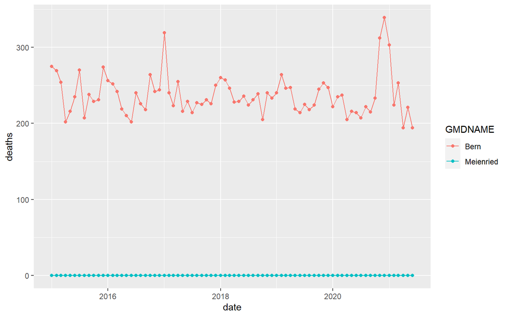

## All time series

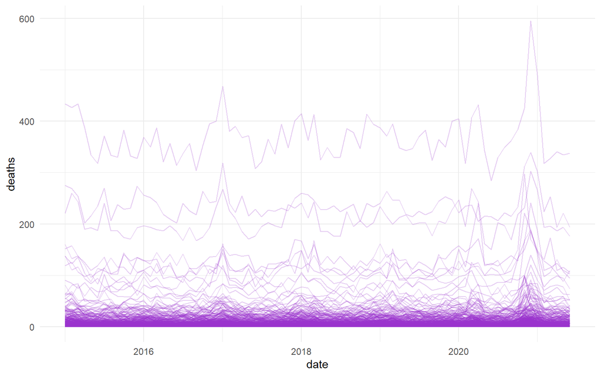

# Aggregating to labour market areas

## Preps

```r
s_deaths_2015_2021_ar <- s_deaths_2015_2021_exp %>%
  select(-GMDNR, -GMDNAME) %>%
  group_by(ARGRNR, ARGRNAME, ARNR, ARNAME,
           KTNAME, year, month, date, age, sex, nationality) %>%
  summarise(deaths = as.integer(sum(deaths))) %>%
  ungroup()
```

That reduces the size of the dataset to 273,312.

Proportion of zero cells:

```
deaths == 0 <lgl>
# total N=273312 valid N=273312 mean=0.69 sd=0.46

Value |      N | Raw % | Valid % | Cum. %
-----------------------------------------
FALSE |  84664 | 30.98 |   30.98 |  30.98
TRUE  | 188648 | 69.02 |   69.02 | 100.00
<NA>  |      0 |  0.00 |    <NA> |   <NA>
```

And with exclusion of `<40` age group stratum:

```
deaths == 0 <lgl>
# total N=227760 valid N=227760 mean=0.65 sd=0.48

Value |      N | Raw % | Valid % | Cum. %
-----------------------------------------
FALSE |  79225 | 34.78 |   34.78 |  34.78
TRUE  | 148535 | 65.22 |   65.22 | 100.00
<NA>  |      0 |  0.00 |    <NA> |   <NA>
```

## Examples of time series

### Districts Bern & Biel/Bienne

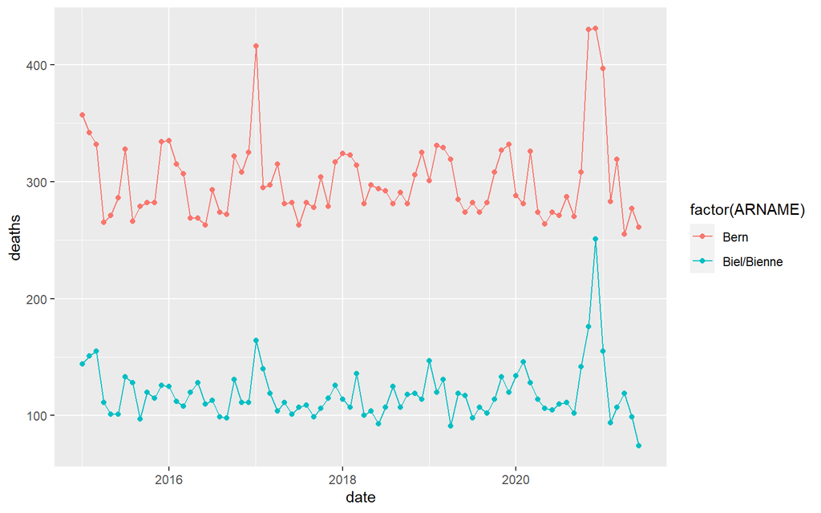

## All time series

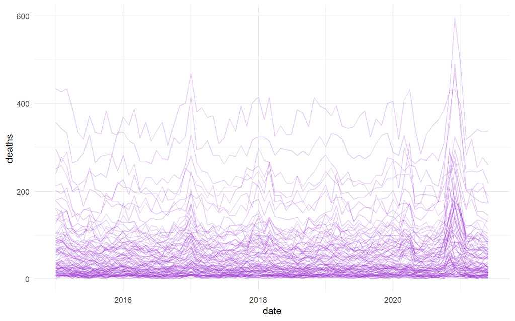